# Tugas MPDW Pertemuan 4

Abdullah Zeith Alfarizy (G1401231060)

2025-09-22

### white noise

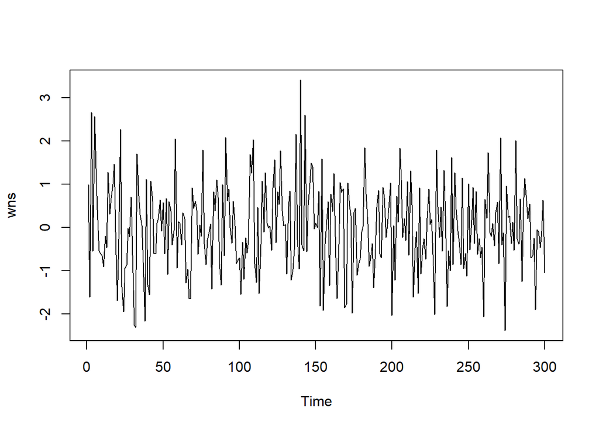

```r
set.seed(1060)
wns <- rnorm(300)
ts.plot(wns)
```

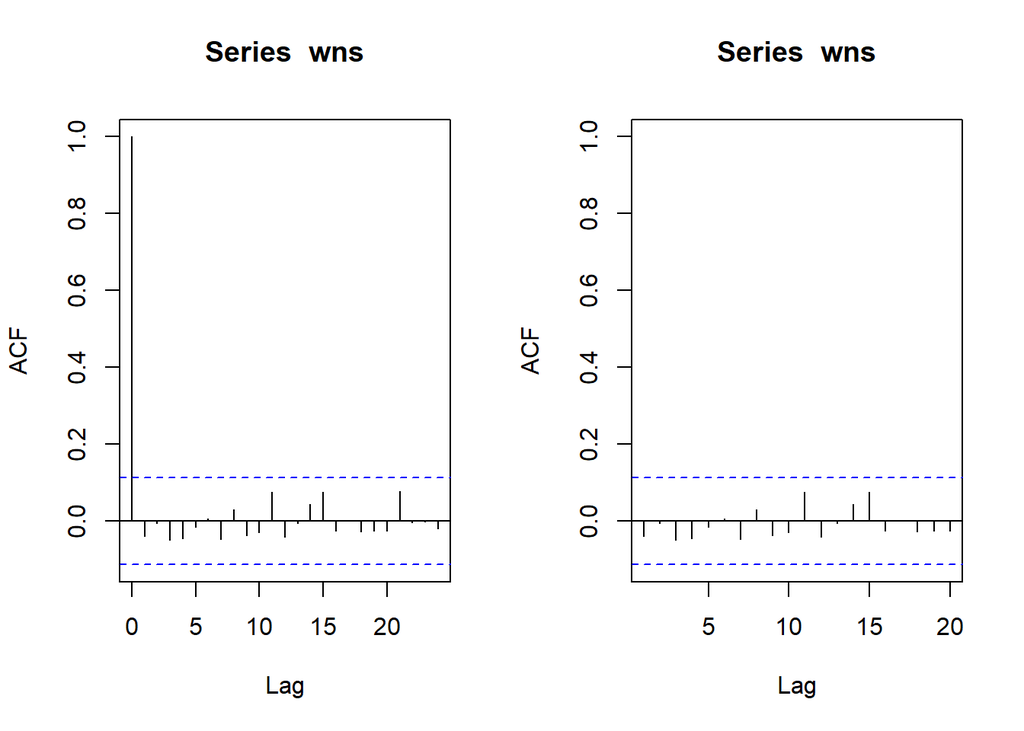

```r
par(mfrow = c(1, 2))
acf(wns)
acf(wns, xlim = c(1, 20))
```

Berdasarkan plot acf diatas terlihat bahwa *white noise* tidak memiliki autokorelasi. Lag ke-0 adalah korelasi observasi ke-t dengan dirinya sendiri dan nilai korelasinya sudah pasti 1.

# Proses MA

Proses MA secara umum :
$$y_{t} = c + e_t + \theta_{1}e_{t-1} + \theta_{2}e_{t-2} + \dots +
\theta_{q}e_{t-q} = c+{e_t+\sum_{i=1}^p \theta_ie_{t-i}}$$

## Pembangkitan Proses MA(2)

$$y_t = e_t+0.4e_{t-1}+0.6e_{t-2}$$

Akan dibangkitkan proses MA(2) dengan $\theta1 = 0.4$ dan $\theta2 = 0.6$ sebanyak 300 observasi dan $c=0$. Karena diperlukan dua nilai awal untuk $e_{t-1}$ dan $e_{t-2}$ maka masukkan dua nilai pertama white noise sebagai nilai awal.

```r
set.seed(1060)
ma2 <- wns[1:2]
```

```r
for (i in 3:300) {
  ma2[i] <- wns[i] + 0.4 * wns[i - 1] + 0.6 * wns[i - 2]
}
ma2
```

```
##   [1]  0.988730499 -1.607070386  2.613963541 -0.440904013  3.948627634
##   [6]  2.074371276  2.507537144  0.455346849 -0.559287275 -1.215693530
##  [11] -1.529895492 -0.955917955 -1.084617220  0.971955349  0.546350135
##  [16]  1.570237414  1.457140436  2.273292449  0.560771539 -1.065562814
##  [21] -1.320746395  1.144015761 -0.621193981 -1.129723753 -2.537874883
##  [26] -2.409665337 -0.931481998 -0.744013640  0.602899913 -0.485426434
##  [31] -2.092138156 -3.599777028 -0.582894671  0.025458503  1.608714628
##  [36]  0.606555776 -0.606369990 -2.460450244 -0.231817748 -2.169370127
##  [41] -1.414903120 -0.342830895  0.106020838  0.293426949 -0.472497470
##  [46] -0.490813283 -0.101542611  0.789426560  0.301559095  0.928678216
##  [51] -0.423610390  0.780014768 -1.172427483  0.572163736 -0.026746339
##  [56]  0.114888810 -0.001801675  1.786384525 -0.156294615  0.997391425
##  [61] -0.399568044 -0.276718475  0.243058838  0.104133345 -0.993135030
##  [66] -1.354847282 -2.791072867 -2.887298950 -0.718997137 -0.182900710
##  [71]  1.337490111  0.912752134 -0.089472872  0.062997668 -0.544388008
```

[output cut: 45 more lines]

#### Membangkitkan dengan arima.sim

```r
ma_2 <- arima.sim(list(order=c(0,0,2), ma=c(0.4, 0.6)), n=300)
ma_2
```

```
## Time Series:
## Start = 1
## End = 300
## Frequency = 1
##   [1]  2.613963541 -0.440904013  3.948627634  2.074371276  2.507537144
##   [6]  0.455346849 -0.559287275 -1.215693530 -1.529895492 -0.955917955
##  [11] -1.084617220  0.971955349  0.546350135  1.570237414  1.457140436
##  [16]  2.273292449  0.560771539 -1.065562814 -1.320746395  1.144015761
##  [21] -0.621193981 -1.129723753 -2.537874883 -2.409665337 -0.931481998
##  [26] -0.744013640  0.602899913 -0.485426434 -2.092138156 -3.599777028
##  [31] -0.582894671  0.025458503  1.608714628  0.606555776 -0.606369990
##  [36] -2.460450244 -0.231817748 -2.169370127 -1.414903120 -0.342830895
##  [41]  0.106020838  0.293426949 -0.472497470 -0.490813283 -0.101542611
##  [46]  0.789426560  0.301559095  0.928678216 -0.423610390  0.780014768
##  [51] -1.172427483  0.572163736 -0.026746339  0.114888810 -0.001801675
```

[output cut: 49 more lines]

## Karakteristik MA(2)

### Plot Time Series

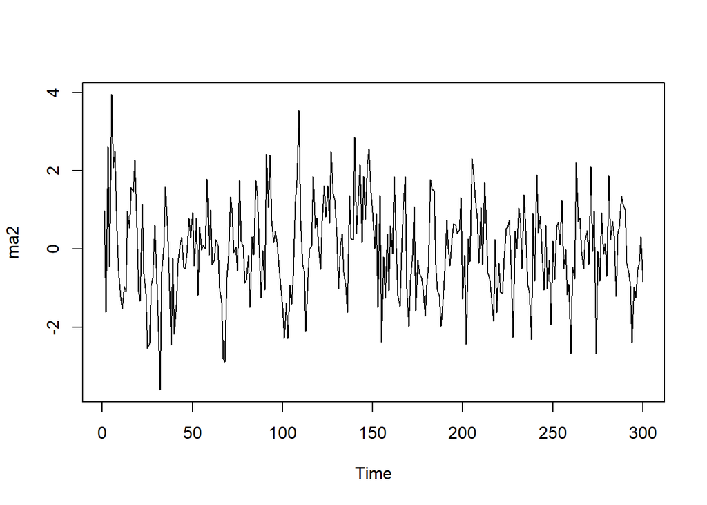

```r
ts.plot(ma2)
```

Berdasarkan plot time series, terlihat bahwa data MA(2) yang dibangkitkan bergerak di sekitar rataannya atau dapat dikatakan MA(2) sudah stasioner dalam rataan.

### Plot ACF

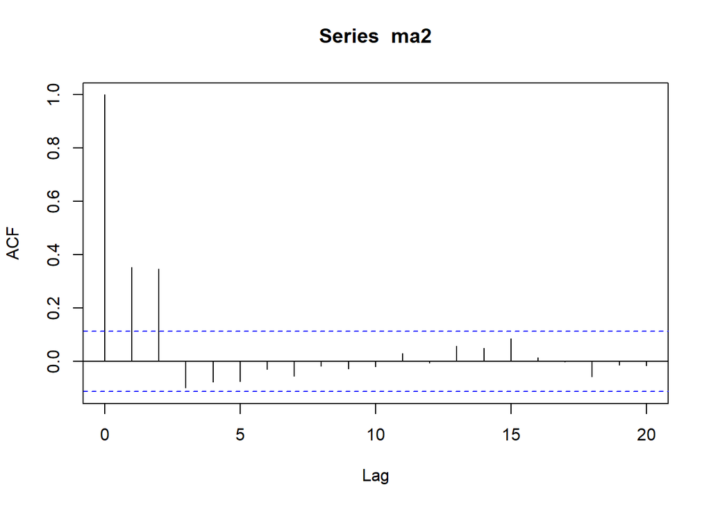

```r
acf(ma2,lag.max = 20)
```

Berdasarkan plot ACF tersebut, terlihat bahwa plot ACF *cuts off* di dua lag pertama (sudah sesuai dengan karakteristik MA secara teoritis dimana MA(1) pada plot ACF akan cut off pada lag pertama, MA(2) akan cut off pada 2 lag pertama dan seterusnya).

### Plot PACF

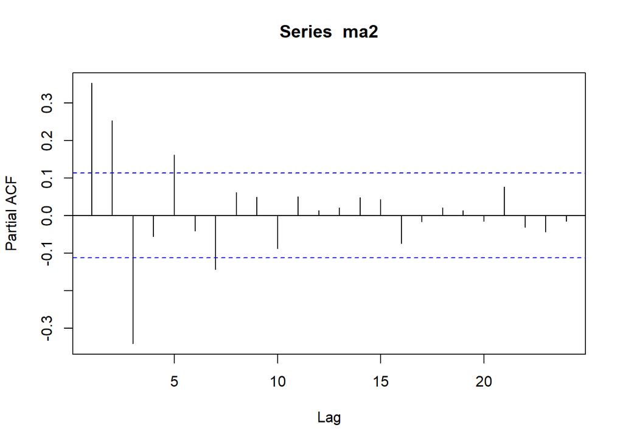

```r
pacf(ma2)
```

Berdasarkan plot PACF tersebut, terlihat bahwa plot PACF cenderung *tails off* dan membentuk gelombang sinus

### Plot EACF

```r
TSA::eacf(ma2)
```

```
## AR/MA
##   0 1 2 3 4 5 6 7 8 9 10 11 12 13
## 0 x x o o o o o o o o o  o  o  o
## 1 x x x o o o o o o o o  o  o  o
## 2 x x x o o o o o o o o  o  o  o
## 3 x x x x x o o o o o o  o  o  o
## 4 x x x x x o o o o o o  o  o  o
## 5 x x x x x o o o o o o  o  o  o
## 6 x x x x o o x o o o o  o  o  o
## 7 x x x x x x o x o o o  o  o  o
```

Berdasarkan pola segitiga nol pada plot EACF, terlihat bahwa segitiga nol berada pada ordo AR(0) dan ordo MA(2)

### Scatterplot Antar Lag

#### Korelasi antara $Y_t$ dengan $Y_{t-1}$

```r
#Yt
yt_ma <- ma2[-1]
yt_ma
```

```
##   [1] -1.607070386  2.613963541 -0.440904013  3.948627634  2.074371276
##   [6]  2.507537144  0.455346849 -0.559287275 -1.215693530 -1.529895492
##  [11] -0.955917955 -1.084617220  0.971955349  0.546350135  1.570237414
##  [16]  1.457140436  2.273292449  0.560771539 -1.065562814 -1.320746395
##  [21]  1.144015761 -0.621193981 -1.129723753 -2.537874883 -2.409665337
##  [26] -0.931481998 -0.744013640  0.602899913 -0.485426434 -2.092138156
##  [31] -3.599777028 -0.582894671  0.025458503  1.608714628  0.606555776
##  [36] -0.606369990 -2.460450244 -0.231817748 -2.169370127 -1.414903120
##  [41] -0.342830895  0.106020838  0.293426949 -0.472497470 -0.490813283
##  [46] -0.101542611  0.789426560  0.301559095  0.928678216 -0.423610390
##  [51]  0.780014768 -1.172427483  0.572163736 -0.026746339  0.114888810
##  [56] -0.001801675  1.786384525 -0.156294615  0.997391425 -0.399568044
##  [61] -0.276718475  0.243058838  0.104133345 -0.993135030 -1.354847282
##  [66] -2.791072867 -2.887298950 -0.718997137 -0.182900710  1.337490111
##  [71]  0.912752134 -0.089472872  0.062997668 -0.544388008  1.754435736
```

[output cut: 45 more lines]

```r
#Yt-1
yt_1_ma <- ma2[-300]
yt_1_ma
```

```
##   [1]  0.988730499 -1.607070386  2.613963541 -0.440904013  3.948627634
##   [6]  2.074371276  2.507537144  0.455346849 -0.559287275 -1.215693530
##  [11] -1.529895492 -0.955917955 -1.084617220  0.971955349  0.546350135
##  [16]  1.570237414  1.457140436  2.273292449  0.560771539 -1.065562814
##  [21] -1.320746395  1.144015761 -0.621193981 -1.129723753 -2.537874883
##  [26] -2.409665337 -0.931481998 -0.744013640  0.602899913 -0.485426434
##  [31] -2.092138156 -3.599777028 -0.582894671  0.025458503  1.608714628
##  [36]  0.606555776 -0.606369990 -2.460450244 -0.231817748 -2.169370127
##  [41] -1.414903120 -0.342830895  0.106020838  0.293426949 -0.472497470
##  [46] -0.490813283 -0.101542611  0.789426560  0.301559095  0.928678216
##  [51] -0.423610390  0.780014768 -1.172427483  0.572163736 -0.026746339
##  [56]  0.114888810 -0.001801675  1.786384525 -0.156294615  0.997391425
##  [61] -0.399568044 -0.276718475  0.243058838  0.104133345 -0.993135030
##  [66] -1.354847282 -2.791072867 -2.887298950 -0.718997137 -0.182900710
##  [71]  1.337490111  0.912752134 -0.089472872  0.062997668 -0.544388008
```

[output cut: 45 more lines]

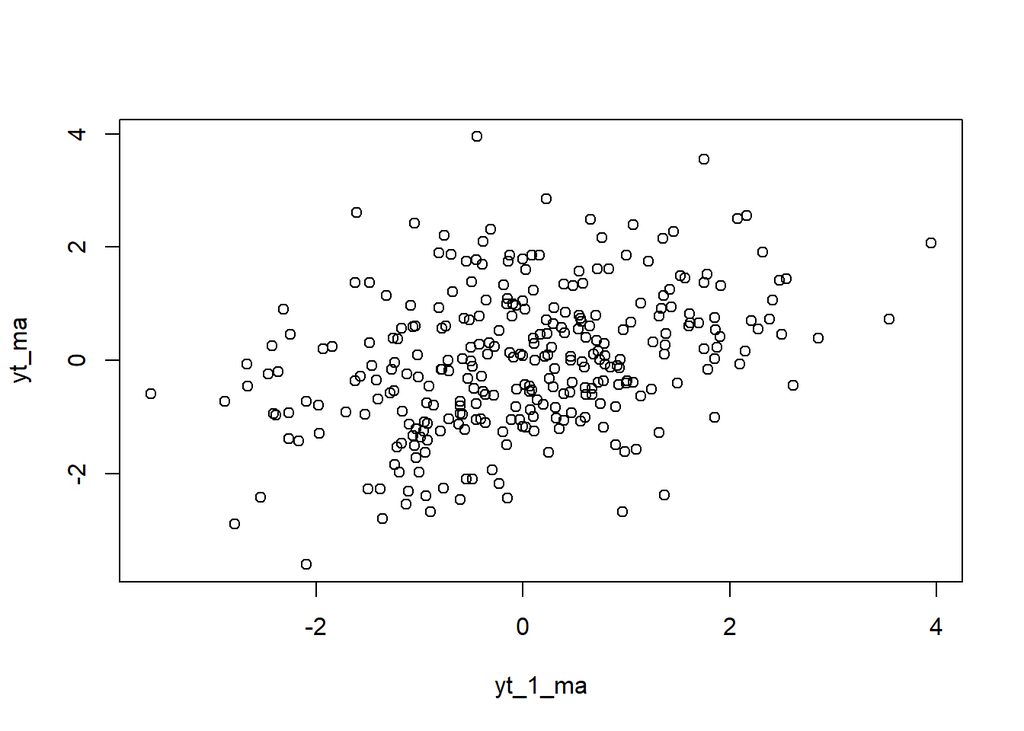

```r
plot(y=yt_ma,x=yt_1_ma)
```

Berdasarkan scatterplot tersebut, walaupun terlihat cukup acak namun masih bisa diidentifikas bahwa terdapat hubungan positif antara $Y_t$ dengan $Y_{t-1}$.

```r
cor(yt_ma,yt_1_ma)
```

```
## [1] 0.3535921
```

#### Korelasi antara $Y_t$ dengan $Y_{t-2}$

```r
#Yt
yt_ma2 <- ma2[-c(1,2)]
yt_ma2
```

```
##   [1]  2.613963541 -0.440904013  3.948627634  2.074371276  2.507537144
##   [6]  0.455346849 -0.559287275 -1.215693530 -1.529895492 -0.955917955
##  [11] -1.084617220  0.971955349  0.546350135  1.570237414  1.457140436
##  [16]  2.273292449  0.560771539 -1.065562814 -1.320746395  1.144015761
##  [21] -0.621193981 -1.129723753 -2.537874883 -2.409665337 -0.931481998
##  [26] -0.744013640  0.602899913 -0.485426434 -2.092138156 -3.599777028
##  [31] -0.582894671  0.025458503  1.608714628  0.606555776 -0.606369990
##  [36] -2.460450244 -0.231817748 -2.169370127 -1.414903120 -0.342830895
##  [41]  0.106020838  0.293426949 -0.472497470 -0.490813283 -0.101542611
##  [46]  0.789426560  0.301559095  0.928678216 -0.423610390  0.780014768
##  [51] -1.172427483  0.572163736 -0.026746339  0.114888810 -0.001801675
##  [56]  1.786384525 -0.156294615  0.997391425 -0.399568044 -0.276718475
##  [61]  0.243058838  0.104133345 -0.993135030 -1.354847282 -2.791072867
##  [66] -2.887298950 -0.718997137 -0.182900710  1.337490111  0.912752134
##  [71] -0.089472872  0.062997668 -0.544388008  1.754435736  0.211949141
```

[output cut: 45 more lines]

```r
#Yt-2
yt_2_ma <- ma2[-c(299,300)]
yt_2_ma
```

```
##   [1]  0.988730499 -1.607070386  2.613963541 -0.440904013  3.948627634
##   [6]  2.074371276  2.507537144  0.455346849 -0.559287275 -1.215693530
##  [11] -1.529895492 -0.955917955 -1.084617220  0.971955349  0.546350135
##  [16]  1.570237414  1.457140436  2.273292449  0.560771539 -1.065562814
##  [21] -1.320746395  1.144015761 -0.621193981 -1.129723753 -2.537874883
##  [26] -2.409665337 -0.931481998 -0.744013640  0.602899913 -0.485426434
##  [31] -2.092138156 -3.599777028 -0.582894671  0.025458503  1.608714628
##  [36]  0.606555776 -0.606369990 -2.460450244 -0.231817748 -2.169370127
##  [41] -1.414903120 -0.342830895  0.106020838  0.293426949 -0.472497470
##  [46] -0.490813283 -0.101542611  0.789426560  0.301559095  0.928678216
##  [51] -0.423610390  0.780014768 -1.172427483  0.572163736 -0.026746339
##  [56]  0.114888810 -0.001801675  1.786384525 -0.156294615  0.997391425
##  [61] -0.399568044 -0.276718475  0.243058838  0.104133345 -0.993135030
##  [66] -1.354847282 -2.791072867 -2.887298950 -0.718997137 -0.182900710
##  [71]  1.337490111  0.912752134 -0.089472872  0.062997668 -0.544388008
```

[output cut: 45 more lines]

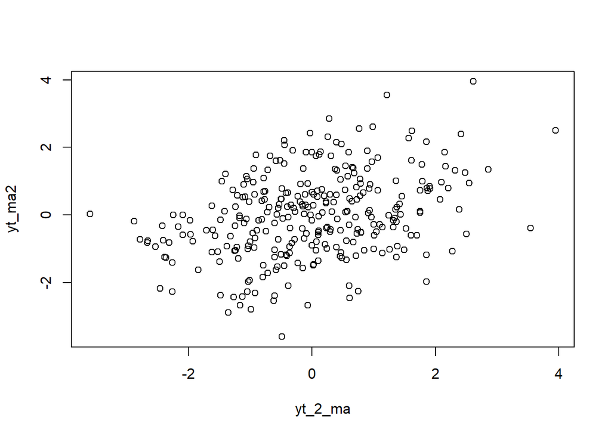

```r
plot(y=yt_ma2,x=yt_2_ma)
```

Berdasarkan scatterplot tersebut pola korelasi yang terlihat tidak jauh berbeda dengan korelasi antara $Y_t$ dengan $Y_{t-1}$, dimana terlihat bahwa terdapat hubungan positif antara $Y_t$ dengan $Y_{t-2}$.

```r
cor(yt_ma2,yt_2_ma)
```

```
## [1] 0.3476457
```

#### Korelasi antara $Y_t$ dengan $Y_{t-3}$

```r
#Yt
yt_ma3 <- ma2[-c(1,2,3)]
yt_ma3
```

```
##   [1] -0.440904013  3.948627634  2.074371276  2.507537144  0.455346849
##   [6] -0.559287275 -1.215693530 -1.529895492 -0.955917955 -1.084617220
##  [11]  0.971955349  0.546350135  1.570237414  1.457140436  2.273292449
##  [16]  0.560771539 -1.065562814 -1.320746395  1.144015761 -0.621193981
##  [21] -1.129723753 -2.537874883 -2.409665337 -0.931481998 -0.744013640
##  [26]  0.602899913 -0.485426434 -2.092138156 -3.599777028 -0.582894671
##  [31]  0.025458503  1.608714628  0.606555776 -0.606369990 -2.460450244
##  [36] -0.231817748 -2.169370127 -1.414903120 -0.342830895  0.106020838
##  [41]  0.293426949 -0.472497470 -0.490813283 -0.101542611  0.789426560
##  [46]  0.301559095  0.928678216 -0.423610390  0.780014768 -1.172427483
##  [51]  0.572163736 -0.026746339  0.114888810 -0.001801675  1.786384525
##  [56] -0.156294615  0.997391425 -0.399568044 -0.276718475  0.243058838
##  [61]  0.104133345 -0.993135030 -1.354847282 -2.791072867 -2.887298950
##  [66] -0.718997137 -0.182900710  1.337490111  0.912752134 -0.089472872
##  [71]  0.062997668 -0.544388008  1.754435736  0.211949141  0.070603421
```

[output cut: 45 more lines]

```r
#Yt-2
yt_3_ma <- ma2[-c(298,299,300)]
yt_3_ma
```

```
##   [1]  0.988730499 -1.607070386  2.613963541 -0.440904013  3.948627634
##   [6]  2.074371276  2.507537144  0.455346849 -0.559287275 -1.215693530
##  [11] -1.529895492 -0.955917955 -1.084617220  0.971955349  0.546350135
##  [16]  1.570237414  1.457140436  2.273292449  0.560771539 -1.065562814
##  [21] -1.320746395  1.144015761 -0.621193981 -1.129723753 -2.537874883
##  [26] -2.409665337 -0.931481998 -0.744013640  0.602899913 -0.485426434
##  [31] -2.092138156 -3.599777028 -0.582894671  0.025458503  1.608714628
##  [36]  0.606555776 -0.606369990 -2.460450244 -0.231817748 -2.169370127
##  [41] -1.414903120 -0.342830895  0.106020838  0.293426949 -0.472497470
##  [46] -0.490813283 -0.101542611  0.789426560  0.301559095  0.928678216
##  [51] -0.423610390  0.780014768 -1.172427483  0.572163736 -0.026746339
##  [56]  0.114888810 -0.001801675  1.786384525 -0.156294615  0.997391425
##  [61] -0.399568044 -0.276718475  0.243058838  0.104133345 -0.993135030
##  [66] -1.354847282 -2.791072867 -2.887298950 -0.718997137 -0.182900710
##  [71]  1.337490111  0.912752134 -0.089472872  0.062997668 -0.544388008
```

[output cut: 45 more lines]

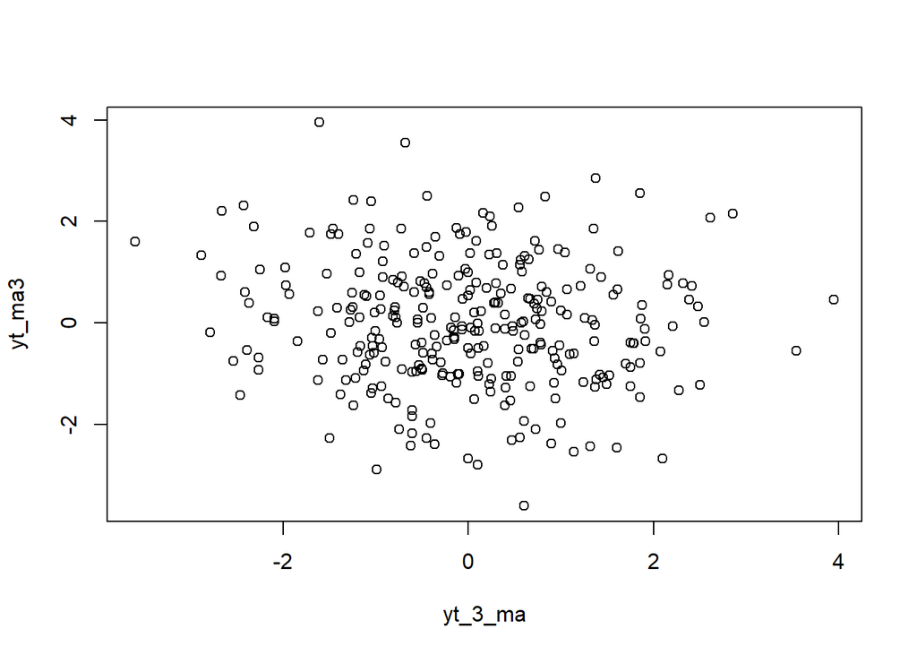

```r
plot(y=yt_ma3,x=yt_3_ma)
```

Berdasarkan scatterplot tersebut, terlihat bahwa cenderung tidak terdapat hubungan antara $Y_t$ dengan $Y_{t-3}$.

```r
cor(yt_ma3,yt_3_ma)
```

```
## [1] -0.1006938
```

### Korelasi Secara Teoritis

$$\rho_1 = \frac{\gamma_1}{\gamma_0}
= \frac{\theta_1 + \theta_1 \theta_2}{1 + \theta_1^2 + \theta_2^2}
= \frac{0.4 + (0.4)(0.6)}{1 + 0.4^2 + 0.6^2}
= \frac{0.64}{1.52}
= 0.4211$$

$$\rho_2 = \frac{\gamma_2}{\gamma_0}
= \frac{\theta_2}{1 + \theta_1^2 + \theta_2^2}
= \frac{0.6}{1.52}
= 0.3947$$

### Jika dibuat dalam syntax sebagai berikut :

```r
# Parameter
theta1 <- 0.4
theta2 <- 0.6
sigma2 <- 1  # Varian white noise

# Autokovarians
gamma0 <- (1 + theta1^2 + theta2^2) * sigma2
gamma1 <- (theta1 + theta1 * theta2) * sigma2
gamma2 <- theta2 * sigma2

# Autokorelasi teoritis
rho1 <- gamma1 / gamma0
rho2 <- gamma2 / gamma0
rho3 <- 0  # MA(2) -> ρk = 0 untuk k > 2

cat("ρ1 =", rho1, "\n")
```

```
## ρ1 = 0.4210526
```

```r
cat("ρ2 =", rho2, "\n")
```

```
## ρ2 = 0.3947368
```

```r
cat("ρ3 =", rho3, "\n")
```

```
## ρ3 = 0
```

Korelasi antara $Y_t$ dengan $Y_{t-1}$ dan korelasi antara $Y_t$ dengan $Y_{t-2}$ dari hasil simulasi cukup mendekati perhitungan teoritis sedangkan untuk korelasi $Y_t$ dengan $Y_{t-3}$ secara teori akan == 0.

# Proses AR

Proses AR dapat dituliskan sebagai berikut:

$$y_{t} = c + e_t + \phi_{1}Y_{t-1} + \phi_{2}Y_{t-2} + \dots +
\phi_{q}Y_{t-q} = c+{e_t+\sum_{i=1}^p \phi_iY_{t-i}}$$

## Pembangkitan Proses AR(2)

Akan ddibangkitkan proses AR(2) dengan $\phi = 0.5$ dan $\phi = 0.2$ sebanyak 300 observasi dan $c=0$.

$$Y_t = e_t+0.5Y_{t-1}+0.2Y_{t-2}$$

```r
set.seed(1060)
```

```r
n <-length(wns)
n
```

```
## [1] 300
```

```r
ar2 <- c(1:n)
for (i in 3:n) {
  ar2[i] <- wns[i] + 0.5 * ar2[i - 1] + 0.2 * ar2[i - 2]
}
ar2
```

```
##   [1]  1.000000000  2.000000000  3.863553396  1.789693559  4.234886311
##   [6]  3.848071486  3.189076990  1.828660276  0.956216877  0.187813937
##  [11] -0.624777330 -0.473156829 -0.820862116  0.769622791  0.532711963
##  [16]  1.100877628  1.654639013  2.513366105  0.963439281 -0.711023967
##  [21] -0.430900847  1.910841329 -0.498506072 -1.810807823 -1.944842848
##  [26] -2.202119405 -1.510653070 -1.410992287 -0.306255217 -1.072155993
##  [31] -2.855558149 -3.956597701 -0.851612714 -0.482154045 -0.115352338
##  [36] -0.106953204 -0.879406905 -2.628692668 -0.373290132 -2.027969615
##  [41] -2.647474098 -0.659277752 -0.245835387 -0.848697550 -1.076422585
##  [46] -0.601246809 -0.298388091  0.368952825  0.040487498  0.673399310
##  [51] -0.259972456  0.678997248 -0.791783029  0.339204367  0.392352964
##  [56] -0.133114649 -0.059700036  1.996836101  0.051827792  0.564547213
##  [61]  0.398154833 -0.090497542  0.375125394  0.378789895 -1.016891605
##  [66] -1.400606477 -2.538799986 -3.202021676 -1.185696761 -0.793882823
##  [71] -0.026183054  0.234103023 -0.504785044 -0.139516940 -0.371565511
```

[output cut: 45 more lines]

### Membangkitkan dengan arima.sim

```r
ar_2 <- arima.sim(list(order=c(2,0,0), ar=c(0.5, 0.2)), n=300)
ar_2
```

```
## Time Series:
## Start = 1
## End = 300
## Frequency = 1
##   [1] -2.205561166 -1.513276888 -1.412992548 -0.307780111 -1.073318492
##   [6] -2.856444378 -3.957273315 -0.852127767 -0.482546694 -0.115651673
##  [11] -0.107181402 -0.879580871 -2.628825290 -0.373391237 -2.028046692
##  [16] -2.647532857 -0.659322547 -0.245869537 -0.848723583 -1.076442432
##  [21] -0.601261939 -0.298399625  0.368944031  0.040480794  0.673394199
##  [26] -0.259976352  0.678994278 -0.791785293  0.339202641  0.392351648
##  [31] -0.133115652 -0.059700801  1.996835518  0.051827347  0.564546874
##  [36]  0.398154575 -0.090497739  0.375125243  0.378789780 -1.016891692
##  [41] -1.400606543 -2.538800037 -3.202021715 -1.185696791 -0.793882846
##  [46] -0.026183072  0.234103010 -0.504785053 -0.139516948 -0.371565517
##  [51]  1.581456614  0.330817259 -0.370543106 -0.410411836 -0.438526680
```

[output cut: 49 more lines]

## Karakteristik AR(2)

### Plot Time Series

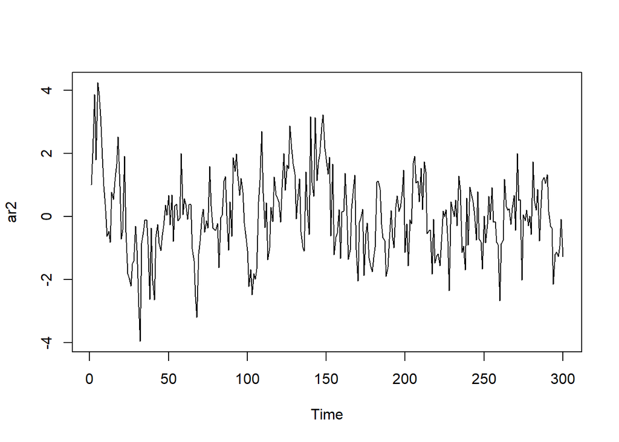

```r
ts.plot(ar2)
```

Berdasarkan plot time series, terlihat bahwa data AR(2) yang dibangkitkan bergerak di sekitar rataannya atau dapat dikatakan AR(2) sudah stasioner dalam rataan

### Plot ACF

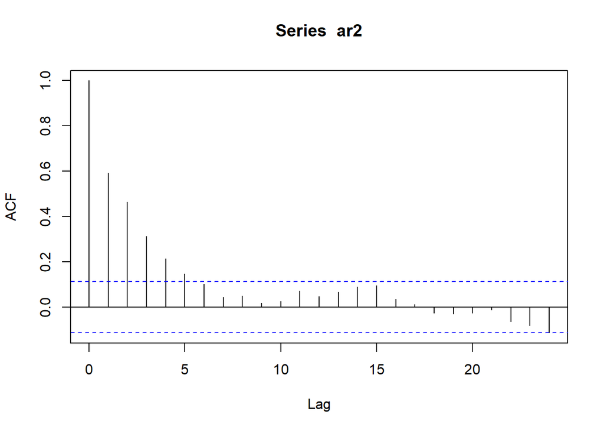

```r
acf(ar2)
```

Berdasarkan plot ACF tersebut terlihat bahwa plot ACF cenderung *tails off*.

### Plot PACF

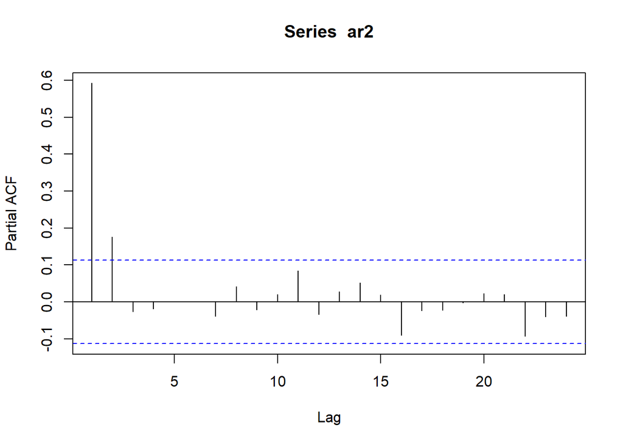

```r
pacf(ar2)
```

Berdasarkan plot PACF tersebut, terlihat bahwa plot PACF *cuts off* pada dua lag pertama, sejalan dengan teori yang ada.

### Plot EACF

```r
TSA::eacf(ar2)
```

```
## AR/MA
##   0 1 2 3 4 5 6 7 8 9 10 11 12 13
## 0 x x x x x o o o o o o  o  o  o
## 1 x o o o o o o o o o o  o  o  o
## 2 o o o o o o o o o o o  o  o  o
## 3 x o o o o o o o o o o  o  o  o
## 4 x x o o o o o o o o o  o  o  o
## 5 x x o o o o o o o o o  o  o  o
## 6 x x o o o o o o o o o  o  o  o
## 7 x x x o o o o o o o o  o  o  o
```

Berdasarkan pola segitiga nol pada plot EACF, terlihat bahwa segitiga nol berada pada ordo AR(2) dan ordo MA(0).

### Scatterplot Antar Lag

#### Korelasi antara $Y_t$ dengan $Y_{t-1}$

```r
#Yt
yt_ar <- ar2[-1]
yt_ar
```

```
##   [1]  2.000000000  3.863553396  1.789693559  4.234886311  3.848071486
##   [6]  3.189076990  1.828660276  0.956216877  0.187813937 -0.624777330
##  [11] -0.473156829 -0.820862116  0.769622791  0.532711963  1.100877628
##  [16]  1.654639013  2.513366105  0.963439281 -0.711023967 -0.430900847
##  [21]  1.910841329 -0.498506072 -1.810807823 -1.944842848 -2.202119405
##  [26] -1.510653070 -1.410992287 -0.306255217 -1.072155993 -2.855558149
##  [31] -3.956597701 -0.851612714 -0.482154045 -0.115352338 -0.106953204
##  [36] -0.879406905 -2.628692668 -0.373290132 -2.027969615 -2.647474098
##  [41] -0.659277752 -0.245835387 -0.848697550 -1.076422585 -0.601246809
##  [46] -0.298388091  0.368952825  0.040487498  0.673399310 -0.259972456
##  [51]  0.678997248 -0.791783029  0.339204367  0.392352964 -0.133114649
##  [56] -0.059700036  1.996836101  0.051827792  0.564547213  0.398154833
##  [61] -0.090497542  0.375125394  0.378789895 -1.016891605 -1.400606477
##  [66] -2.538799986 -3.202021676 -1.185696761 -0.793882823 -0.026183054
##  [71]  0.234103023 -0.504785044 -0.139516940 -0.371565511  1.581456619
```

[output cut: 45 more lines]

```r
#Yt-1
yt_1_ar <- ar2[-300]
yt_1_ar
```

```
##   [1]  1.000000000  2.000000000  3.863553396  1.789693559  4.234886311
##   [6]  3.848071486  3.189076990  1.828660276  0.956216877  0.187813937
##  [11] -0.624777330 -0.473156829 -0.820862116  0.769622791  0.532711963
##  [16]  1.100877628  1.654639013  2.513366105  0.963439281 -0.711023967
##  [21] -0.430900847  1.910841329 -0.498506072 -1.810807823 -1.944842848
##  [26] -2.202119405 -1.510653070 -1.410992287 -0.306255217 -1.072155993
##  [31] -2.855558149 -3.956597701 -0.851612714 -0.482154045 -0.115352338
##  [36] -0.106953204 -0.879406905 -2.628692668 -0.373290132 -2.027969615
##  [41] -2.647474098 -0.659277752 -0.245835387 -0.848697550 -1.076422585
##  [46] -0.601246809 -0.298388091  0.368952825  0.040487498  0.673399310
##  [51] -0.259972456  0.678997248 -0.791783029  0.339204367  0.392352964
##  [56] -0.133114649 -0.059700036  1.996836101  0.051827792  0.564547213
##  [61]  0.398154833 -0.090497542  0.375125394  0.378789895 -1.016891605
##  [66] -1.400606477 -2.538799986 -3.202021676 -1.185696761 -0.793882823
##  [71] -0.026183054  0.234103023 -0.504785044 -0.139516940 -0.371565511
```

[output cut: 45 more lines]

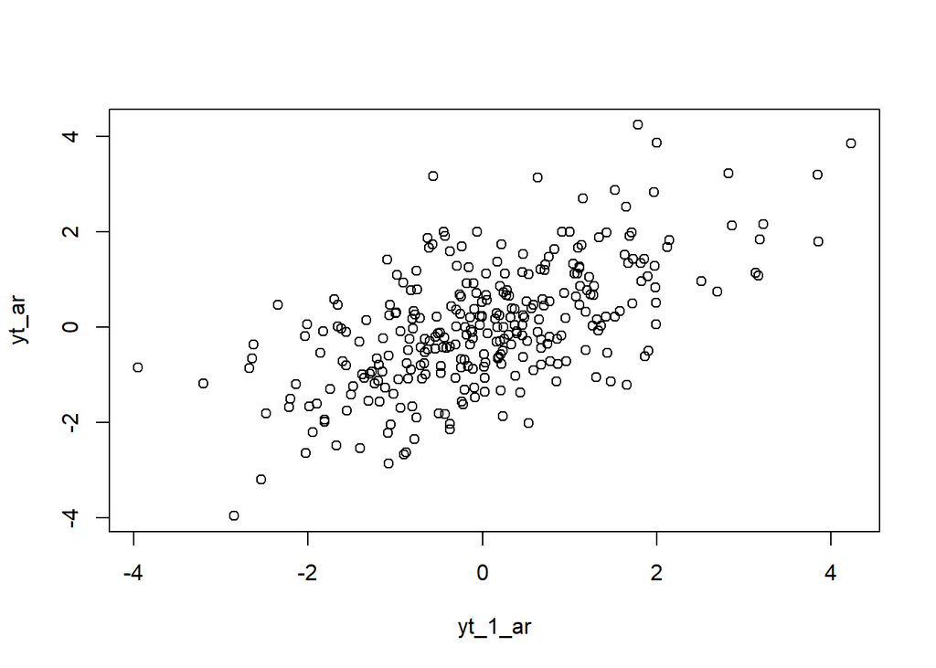

```r
plot(y=yt_ar,x=yt_1_ar)
```

Berdasarkan scatterplot tersebut, terlihat bahwa terdapat hubungan positif yang cukup kuat antara $Y_t$ dengan $Y_{t-1}$.

```r
cor(yt_ar,yt_1_ar)
```

```
## [1] 0.5933792
```

#### Korelasi antara $Y_t$ dengan $Y_{t-2}$

```r
#Yt
yt_ar2 <- ar2[-c(1,2)]
yt_ar2
```

```
##   [1]  3.863553396  1.789693559  4.234886311  3.848071486  3.189076990
##   [6]  1.828660276  0.956216877  0.187813937 -0.624777330 -0.473156829
##  [11] -0.820862116  0.769622791  0.532711963  1.100877628  1.654639013
##  [16]  2.513366105  0.963439281 -0.711023967 -0.430900847  1.910841329
##  [21] -0.498506072 -1.810807823 -1.944842848 -2.202119405 -1.510653070
##  [26] -1.410992287 -0.306255217 -1.072155993 -2.855558149 -3.956597701
##  [31] -0.851612714 -0.482154045 -0.115352338 -0.106953204 -0.879406905
##  [36] -2.628692668 -0.373290132 -2.027969615 -2.647474098 -0.659277752
##  [41] -0.245835387 -0.848697550 -1.076422585 -0.601246809 -0.298388091
##  [46]  0.368952825  0.040487498  0.673399310 -0.259972456  0.678997248
##  [51] -0.791783029  0.339204367  0.392352964 -0.133114649 -0.059700036
##  [56]  1.996836101  0.051827792  0.564547213  0.398154833 -0.090497542
##  [61]  0.375125394  0.378789895 -1.016891605 -1.400606477 -2.538799986
##  [66] -3.202021676 -1.185696761 -0.793882823 -0.026183054  0.234103023
##  [71] -0.504785044 -0.139516940 -0.371565511  1.581456619  0.330817263
```

[output cut: 45 more lines]

```r
#Yt-2
yt_2_ar <- ar2[-c(299,300)]
yt_2_ar
```

```
##   [1]  1.000000000  2.000000000  3.863553396  1.789693559  4.234886311
##   [6]  3.848071486  3.189076990  1.828660276  0.956216877  0.187813937
##  [11] -0.624777330 -0.473156829 -0.820862116  0.769622791  0.532711963
##  [16]  1.100877628  1.654639013  2.513366105  0.963439281 -0.711023967
##  [21] -0.430900847  1.910841329 -0.498506072 -1.810807823 -1.944842848
##  [26] -2.202119405 -1.510653070 -1.410992287 -0.306255217 -1.072155993
##  [31] -2.855558149 -3.956597701 -0.851612714 -0.482154045 -0.115352338
##  [36] -0.106953204 -0.879406905 -2.628692668 -0.373290132 -2.027969615
##  [41] -2.647474098 -0.659277752 -0.245835387 -0.848697550 -1.076422585
##  [46] -0.601246809 -0.298388091  0.368952825  0.040487498  0.673399310
##  [51] -0.259972456  0.678997248 -0.791783029  0.339204367  0.392352964
##  [56] -0.133114649 -0.059700036  1.996836101  0.051827792  0.564547213
##  [61]  0.398154833 -0.090497542  0.375125394  0.378789895 -1.016891605
##  [66] -1.400606477 -2.538799986 -3.202021676 -1.185696761 -0.793882823
##  [71] -0.026183054  0.234103023 -0.504785044 -0.139516940 -0.371565511
```

[output cut: 45 more lines]

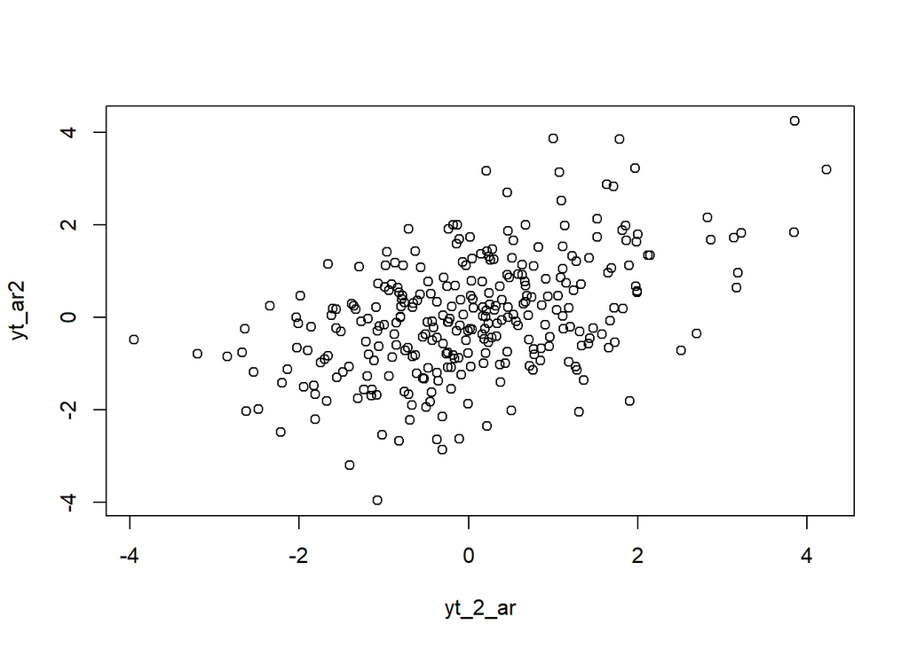

```r
plot(y=yt_ar2,x=yt_2_ar)
```

Berdasarkan scatterplot tersebut, terlihat bahwa terdapat hubungan positif antara $Y_t$ dengan $Y_{t-2}$.

```r
cor(yt_ar2,yt_2_ar)
```

```
## [1] 0.4674073
```

#### Korelasi antara $Y_t$ dengan $Y_{t-3}$

```r
#Yt
yt_ar3 <- ar2[-c(1,2,3)]
yt_ar3
```

```
##   [1]  1.789693559  4.234886311  3.848071486  3.189076990  1.828660276
##   [6]  0.956216877  0.187813937 -0.624777330 -0.473156829 -0.820862116
##  [11]  0.769622791  0.532711963  1.100877628  1.654639013  2.513366105
##  [16]  0.963439281 -0.711023967 -0.430900847  1.910841329 -0.498506072
##  [21] -1.810807823 -1.944842848 -2.202119405 -1.510653070 -1.410992287
##  [26] -0.306255217 -1.072155993 -2.855558149 -3.956597701 -0.851612714
##  [31] -0.482154045 -0.115352338 -0.106953204 -0.879406905 -2.628692668
##  [36] -0.373290132 -2.027969615 -2.647474098 -0.659277752 -0.245835387
##  [41] -0.848697550 -1.076422585 -0.601246809 -0.298388091  0.368952825
##  [46]  0.040487498  0.673399310 -0.259972456  0.678997248 -0.791783029
##  [51]  0.339204367  0.392352964 -0.133114649 -0.059700036  1.996836101
##  [56]  0.051827792  0.564547213  0.398154833 -0.090497542  0.375125394
##  [61]  0.378789895 -1.016891605 -1.400606477 -2.538799986 -3.202021676
##  [66] -1.185696761 -0.793882823 -0.026183054  0.234103023 -0.504785044
##  [71] -0.139516940 -0.371565511  1.581456619  0.330817263 -0.370543103
```

[output cut: 45 more lines]

```r
#Yt-2
yt_3_ar <- ar2[-c(298,299,300)]
yt_3_ar
```

```
##   [1]  1.000000000  2.000000000  3.863553396  1.789693559  4.234886311
##   [6]  3.848071486  3.189076990  1.828660276  0.956216877  0.187813937
##  [11] -0.624777330 -0.473156829 -0.820862116  0.769622791  0.532711963
##  [16]  1.100877628  1.654639013  2.513366105  0.963439281 -0.711023967
##  [21] -0.430900847  1.910841329 -0.498506072 -1.810807823 -1.944842848
##  [26] -2.202119405 -1.510653070 -1.410992287 -0.306255217 -1.072155993
##  [31] -2.855558149 -3.956597701 -0.851612714 -0.482154045 -0.115352338
##  [36] -0.106953204 -0.879406905 -2.628692668 -0.373290132 -2.027969615
##  [41] -2.647474098 -0.659277752 -0.245835387 -0.848697550 -1.076422585
##  [46] -0.601246809 -0.298388091  0.368952825  0.040487498  0.673399310
##  [51] -0.259972456  0.678997248 -0.791783029  0.339204367  0.392352964
##  [56] -0.133114649 -0.059700036  1.996836101  0.051827792  0.564547213
##  [61]  0.398154833 -0.090497542  0.375125394  0.378789895 -1.016891605
##  [66] -1.400606477 -2.538799986 -3.202021676 -1.185696761 -0.793882823
##  [71] -0.026183054  0.234103023 -0.504785044 -0.139516940 -0.371565511
```

[output cut: 45 more lines]

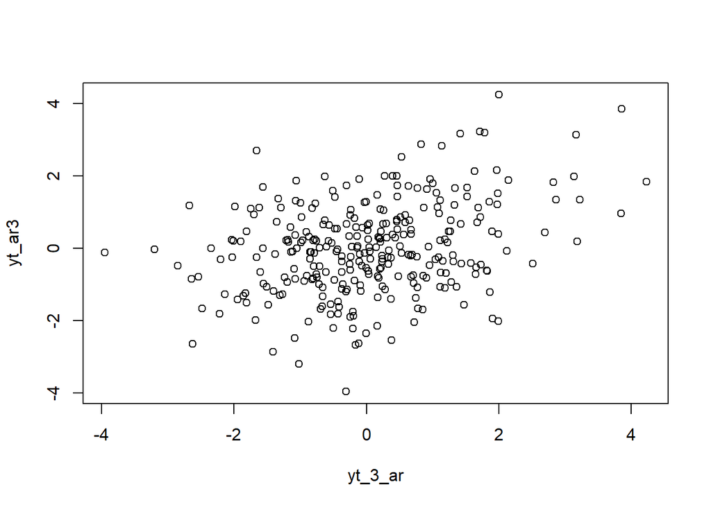

```r
plot(y=yt_ar3,x=yt_3_ar)
```

Berdasarkan scatterplot tersebut, terlihat bahwa masih terdapat hubungan positif antara $Y_t$ dengan $Y_{t-3}$ walaupun terlihat juga bahwa hubungannya tidak terlalu kuat.

```r
cor(yt_ar3,yt_3_ar)
```

```
## [1] 0.3211942
```

#### Korelasi Sercara Teoritis

$$\rho_1 = \frac{\gamma_1}{\gamma_0}
= \frac{\frac{\phi_1}{1 - \phi_2}\gamma_0}{\gamma_0}
= \frac{\phi_1}{1 - \phi_2}
= \frac{0.5}{1 - 0.2}
= 0.625$$

$$\rho_2 = \frac{\gamma_2}{\gamma_0}
= \frac{\phi_1\gamma_1 + \phi_2\gamma_0}{\gamma_0}
= \phi_1\rho_1 + \phi_2
= 0.5(0.625) + 0.2
= 0.5125$$

$$\rho_3 = \phi_1 \rho_2 + \phi_2 \rho_1
= 0.5(0.5125) + 0.2(0.625)
= 0.3813$$

### Jika dibuat dalam syntax

```r
phi1 <- 0.5
phi2 <- 0.2
sigma2 <- 1

# γ1 relatif terhadap γ0
gamma1_over_gamma0 <- phi1 / (1 - phi2)

# γ2 relatif terhadap γ0
gamma2_over_gamma0 <- phi1 * gamma1_over_gamma0 + phi2

# γ0 (varian)
gamma0 <- sigma2 / (1 - phi1 * gamma1_over_gamma0 - phi2 * gamma2_over_gamma0)

# γ1, γ2
gamma1 <- gamma1_over_gamma0 * gamma0
gamma2 <- gamma2_over_gamma0 * gamma0

# Autokorelasi ρ1, ρ2
rho1 <- gamma1 / gamma0
rho2 <- gamma2 / gamma0

# Autokorelasi ρ3 pakai rumus rekursif
rho3 <- phi1 * rho2 + phi2 * rho1

cat("ρ1 =", rho1, "\n")
```

```
## ρ1 = 0.625
```

```r
cat("ρ2 =", rho2, "\n")
```

```
## ρ2 = 0.5125
```

```r
cat("ρ3 =", rho3, "\n")
```

```
## ρ3 = 0.38125
```

Korelasi antara $Y_t$ dengan $Y_{t-1}$, korelasi antara $Y_t$ dengan $Y_{t-2}$ dan korelasi $Y_t$ dengan $Y_{t-3}$ dari hasil simulasi mendekati perhitungan teoritis.

# ARMA (2,2)

## Fungsi pembangkitan ARMA

Proses ARMA secara umum:
$$y_t = c + \phi_1 y_{t-1} + \phi_2 y_{t-2} + \dots + \phi_p y_{t-p} + e_t
+ \theta_1 e_{t-1} + \theta_2 e_{t-2} + \dots + \theta_q e_{t-q}$$

Akan dibangkitkan proses ARMA dengan $\theta1 = 0.4$ dan $\theta2 = 0.6$ , $\phi = 0.5$ dan $\phi = 0.2$ sebanyak 300 observasi dan $c=0$.

$$y_t = 0.5 y_{t-1} + 0.2 y_{t-2} + e_t + 0.4 e_{t-1} + 0.6 e_{t-2}$$

```r
set.seed(1060)
n = length(wns)
theta1 = 0.4
theta2 = 0.6
phi1 = 0.5
phi2 = 0.2

y.arma2=c(1:n)
for (i in 3:n) {
  y.arma2[i] <- phi1*y.arma2[i-1] +
               phi2*y.arma2[i-2] +
               wns[i] +
               theta1*wns[i-1] +
               theta2*wns[i-2]
}
y.arma2
```

```
##   [1]  1.000000000  2.000000000  3.813963541  1.866077758  5.644459221
##   [6]  5.269816438  6.271337208  4.644978741  3.017469537  1.222036986
##  [11] -0.315383091 -0.869202103 -1.582294890  0.006967484  0.233374899
##  [16]  1.688318360  2.347974595  3.784943418  2.922838167  1.152844953
##  [21] -0.159756285  1.294706609 -0.005791933 -0.873678397 -2.975872468
##  [26] -4.072337250 -3.562825116 -3.339893648 -1.779611934 -2.043211131
##  [31] -3.469666108 -5.743252308 -4.148454046 -3.197418982 -0.819685672
##  [36] -0.442770856 -0.991692552 -3.044850692 -1.952581605 -3.754631068
##  [41] -3.682734975 -2.935124596 -2.098088455 -1.342642197 -1.563436260
##  [46] -1.541059852 -1.184759789 -0.111165305  0.009024485  0.910957398
##  [51]  0.033673206  0.979042850 -0.676171416  0.429886598  0.052962677
##  [56]  0.227347468  0.122464594  1.893086315  0.814741462  1.783379419
##  [61]  0.655069958  0.407492387  0.577819024  0.474541335 -0.640300558
##  [66] -1.580089294 -3.709177625 -5.057905622 -3.989785473 -3.189374571
##  [71] -1.055154269 -0.252699915 -0.426853684 -0.200969157 -0.730243323
```

[output cut: 45 more lines]

### Membangkitkan dengan arima.sim

```r
arma22 <- arima.sim(list(order=c(2,0,2), ar=c(0.5, 0.2), ma=c(0.4, 0.6)), n=300)
arma22
```

```
## Time Series:
## Start = 1
## End = 300
## Frequency = 1
##   [1] -3.341346080 -1.780719192 -2.044055246 -3.470309617 -5.743742885
##   [6] -4.148828037 -3.197704093 -0.819903026 -0.442936555 -0.991818873
##  [11] -3.044946992 -1.952655019 -3.754687035 -3.682777642 -2.935157123
##  [16] -2.098113252 -1.342661101 -1.563450671 -1.541070838 -1.184768165
##  [21] -0.111171690  0.009019617  0.910953687  0.033670377  0.979040694
##  [26] -0.676173060  0.429885345  0.052961722  0.227346739  0.122464039
##  [31]  1.893085892  0.814741139  1.783379173  0.655069770  0.407492244
##  [36]  0.577818915  0.474541251 -0.640300621 -1.580089342 -3.709177662
##  [41] -5.057905650 -3.989785494 -3.189374588 -1.055154282 -0.252699925
##  [46] -0.426853691 -0.200969163 -0.730243327  1.349120240  0.740460595
##  [51]  0.710657767 -0.360138723 -0.825017278 -0.641727000 -1.970406921
```

[output cut: 49 more lines]

## Karakteristik ARMA(2,2)

### Plot Time Series

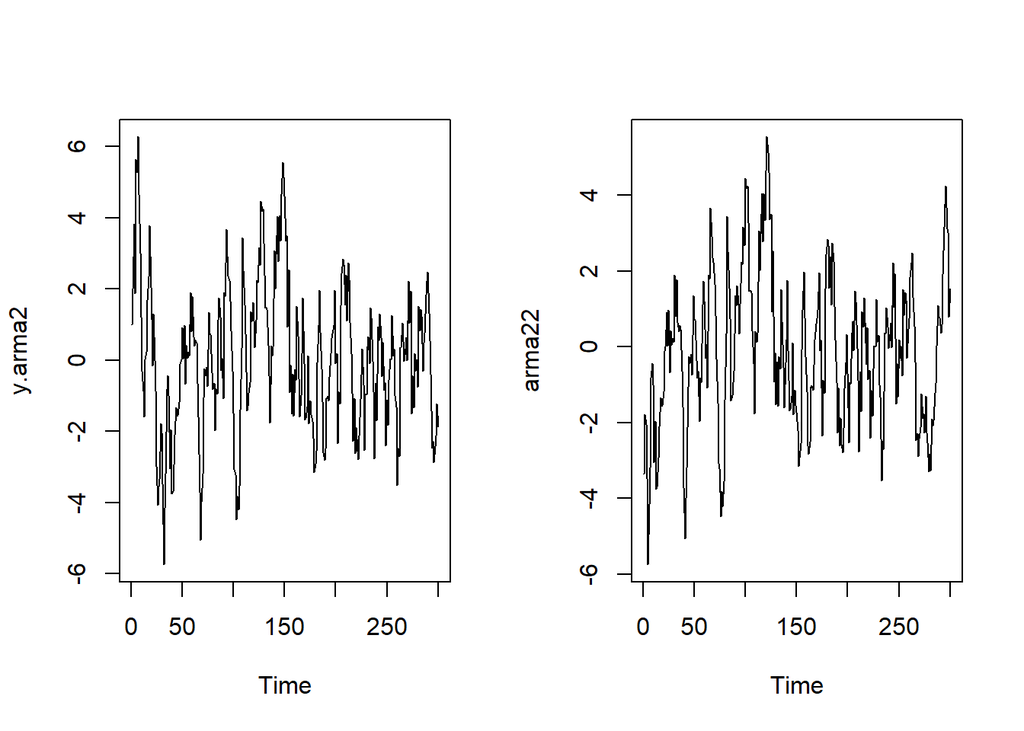

```r
par(mfrow = c(1, 2))
ts.plot(y.arma2)
ts.plot(arma22)
```

```r
par(mfrow = c(1, 1))
```

Berdasarkan plot time series tersebut, terlihat bahwa model ARMA(2,2) baik dari data bangkitan manual ataupun dengan `arima.sim()` keduanya cenderung stasioner dalam rataan.

### Plot ACF

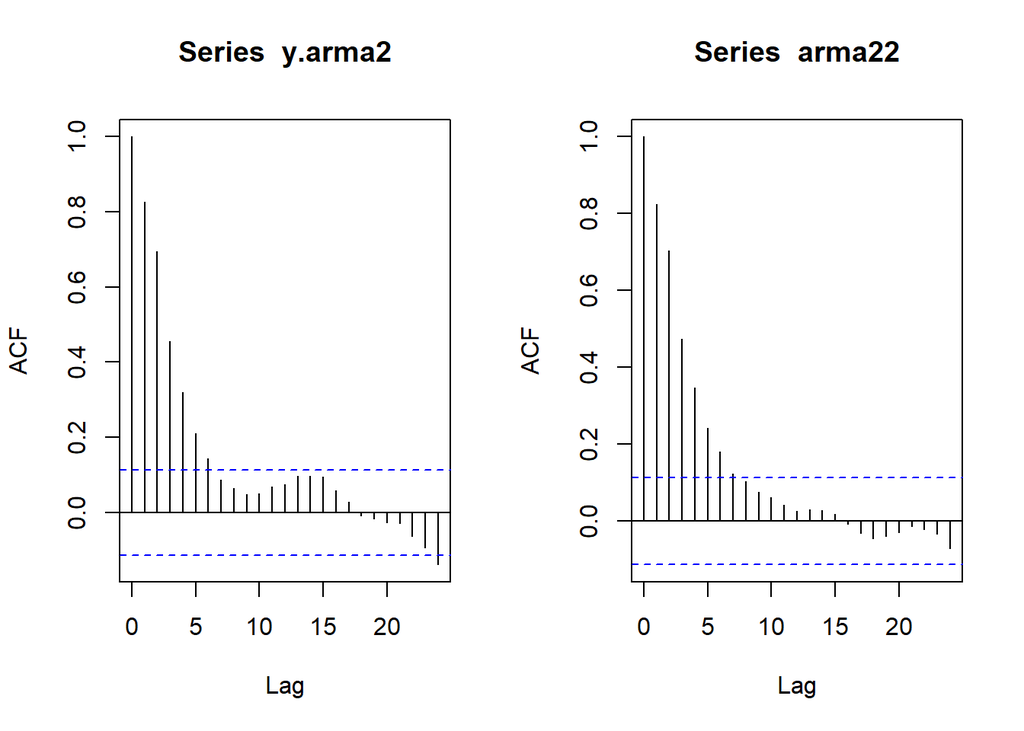

```r
par(mfrow = c(1, 2))
acf(y.arma2)
acf(arma22)
```

```r
par(mfrow = c(1, 1))
```

Berdasarkan plot ACF tersebut, terlihat bahwa model ARMA(2,2) hasil simulasi baik dari data bangkitan manual ataupun dengan `arima.sim()` keduanya memiliki plot ACF yang *tails off*.

### Plot PACF

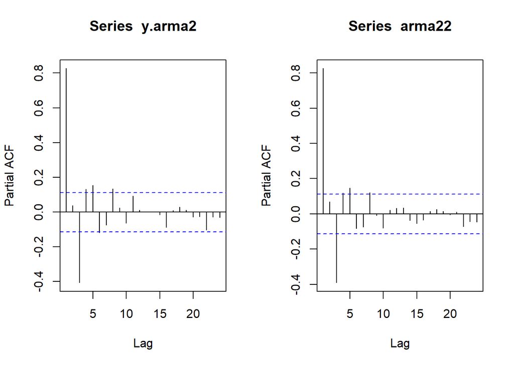

```r
par(mfrow = c(1, 2))
pacf(y.arma2)
pacf(arma22)
```

```r
par(mfrow = c(1, 1))
```

Berdasarkan plot PACF tersebut, terlihat bahwa model ARMA(2,2) hasil simulasi baik dari data bangkitan manual ataupun dengan `arima.sim()` memiliki plot PACF yang *tails off*

### Plot EACF

```r
TSA::eacf(y.arma2)
```

```
## AR/MA
##   0 1 2 3 4 5 6 7 8 9 10 11 12 13
## 0 x x x x x x o o o o o  o  o  o
## 1 o x o o o o o o o o o  o  o  o
## 2 o x o o o o o o o o o  o  o  o
## 3 x x x o o o o o o o o  o  o  o
## 4 x x x o o o o o o o o  o  o  o
## 5 x x x o o o o o o o o  o  o  o
## 6 x x x x o x o o o o o  o  o  o
## 7 x x x o o x o o o o o  o  o  o
```

```r
TSA::eacf(arma22)
```

```
## AR/MA
##   0 1 2 3 4 5 6 7 8 9 10 11 12 13
## 0 x x x x x x x o o o o  o  o  o
## 1 o x x o o o o o o o o  o  o  o
## 2 x x o o o o o o o o o  o  o  o
## 3 x x x x o o o o o o o  o  o  o
## 4 x x x x x o o o o o o  o  o  o
## 5 x x o x o o o o o o o  o  o  o
## 6 x x o o o o o o o o o  o  o  o
## 7 x x x o o o x o o o o  o  o  o
```

### Scatterplot Antar Lag

#### Korelasi antara $Y_t$ dengan $Y_{t-1}$

```r
#Yt
yt_arma <- arma22[-1]
yt_arma
```

```
##   [1] -1.780719192 -2.044055246 -3.470309617 -5.743742885 -4.148828037
##   [6] -3.197704093 -0.819903026 -0.442936555 -0.991818873 -3.044946992
##  [11] -1.952655019 -3.754687035 -3.682777642 -2.935157123 -2.098113252
##  [16] -1.342661101 -1.563450671 -1.541070838 -1.184768165 -0.111171690
##  [21]  0.009019617  0.910953687  0.033670377  0.979040694 -0.676173060
##  [26]  0.429885345  0.052961722  0.227346739  0.122464039  1.893085892
##  [31]  0.814741139  1.783379173  0.655069770  0.407492244  0.577818915
##  [36]  0.474541251 -0.640300621 -1.580089342 -3.709177662 -5.057905650
##  [41] -3.989785494 -3.189374588 -1.055154282 -0.252699925 -0.426853691
##  [46] -0.200969163 -0.730243327  1.349120240  0.740460595  0.710657767
##  [51] -0.360138723 -0.825017278 -0.641727000 -1.970406921 -0.806799685
##  [56] -0.938453620  1.121029890  1.743740251  1.207771243 -0.286853607
##  [61]  0.063882934 -1.072499571  1.895963744  1.799310032  3.667833266
##  [66]  2.922666990  2.366318270  2.233230272  1.655082316  0.821853045
##  [71] -0.308906801 -1.485586663 -3.070203997 -3.212259642 -4.482913418
```

[output cut: 45 more lines]

```r
#Yt-1
yt_1_arma <- arma22[-300]
yt_1_arma
```

```
##   [1] -3.341346080 -1.780719192 -2.044055246 -3.470309617 -5.743742885
##   [6] -4.148828037 -3.197704093 -0.819903026 -0.442936555 -0.991818873
##  [11] -3.044946992 -1.952655019 -3.754687035 -3.682777642 -2.935157123
##  [16] -2.098113252 -1.342661101 -1.563450671 -1.541070838 -1.184768165
##  [21] -0.111171690  0.009019617  0.910953687  0.033670377  0.979040694
##  [26] -0.676173060  0.429885345  0.052961722  0.227346739  0.122464039
##  [31]  1.893085892  0.814741139  1.783379173  0.655069770  0.407492244
##  [36]  0.577818915  0.474541251 -0.640300621 -1.580089342 -3.709177662
##  [41] -5.057905650 -3.989785494 -3.189374588 -1.055154282 -0.252699925
##  [46] -0.426853691 -0.200969163 -0.730243327  1.349120240  0.740460595
##  [51]  0.710657767 -0.360138723 -0.825017278 -0.641727000 -1.970406921
##  [56] -0.806799685 -0.938453620  1.121029890  1.743740251  1.207771243
##  [61] -0.286853607  0.063882934 -1.072499571  1.895963744  1.799310032
##  [66]  3.667833266  2.922666990  2.366318270  2.233230272  1.655082316
##  [71]  0.821853045 -0.308906801 -1.485586663 -3.070203997 -3.212259642
```

[output cut: 45 more lines]

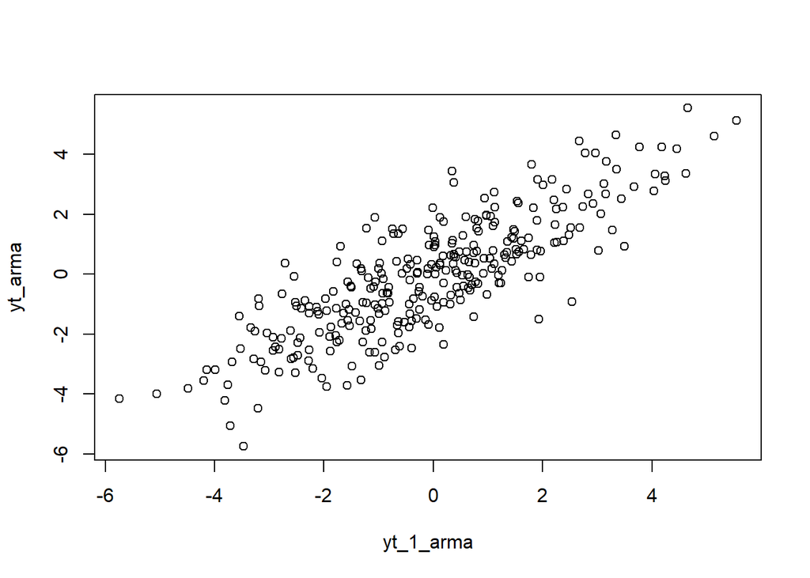

```r
plot(y=yt_arma,x=yt_1_arma)
```

Berdasarkan scatterplot tersebut, terlihat bahwa terdapat hubungan positif yang kuat antara $Y_t$ dengan $Y_{t-1}$.

```r
cor(yt_arma,yt_1_arma)
```

```
## [1] 0.8298434
```

#### Korelasi antara $Y_t$ dengan $Y_{t-2}$

```r
#Yt
yt_arma2 <- arma22[-c(1,2)]
yt_arma2
```

```
##   [1] -2.044055246 -3.470309617 -5.743742885 -4.148828037 -3.197704093
##   [6] -0.819903026 -0.442936555 -0.991818873 -3.044946992 -1.952655019
##  [11] -3.754687035 -3.682777642 -2.935157123 -2.098113252 -1.342661101
##  [16] -1.563450671 -1.541070838 -1.184768165 -0.111171690  0.009019617
##  [21]  0.910953687  0.033670377  0.979040694 -0.676173060  0.429885345
##  [26]  0.052961722  0.227346739  0.122464039  1.893085892  0.814741139
##  [31]  1.783379173  0.655069770  0.407492244  0.577818915  0.474541251
##  [36] -0.640300621 -1.580089342 -3.709177662 -5.057905650 -3.989785494
##  [41] -3.189374588 -1.055154282 -0.252699925 -0.426853691 -0.200969163
##  [46] -0.730243327  1.349120240  0.740460595  0.710657767 -0.360138723
##  [51] -0.825017278 -0.641727000 -1.970406921 -0.806799685 -0.938453620
##  [56]  1.121029890  1.743740251  1.207771243 -0.286853607  0.063882934
##  [61] -1.072499571  1.895963744  1.799310032  3.667833266  2.922666990
##  [66]  2.366318270  2.233230272  1.655082316  0.821853045 -0.308906801
##  [71] -1.485586663 -3.070203997 -3.212259642 -4.482913418 -3.810224905
```

[output cut: 45 more lines]

```r
#Yt-2
yt_2_arma <- arma22[-c(299,300)]
yt_2_arma
```

```
##   [1] -3.341346080 -1.780719192 -2.044055246 -3.470309617 -5.743742885
##   [6] -4.148828037 -3.197704093 -0.819903026 -0.442936555 -0.991818873
##  [11] -3.044946992 -1.952655019 -3.754687035 -3.682777642 -2.935157123
##  [16] -2.098113252 -1.342661101 -1.563450671 -1.541070838 -1.184768165
##  [21] -0.111171690  0.009019617  0.910953687  0.033670377  0.979040694
##  [26] -0.676173060  0.429885345  0.052961722  0.227346739  0.122464039
##  [31]  1.893085892  0.814741139  1.783379173  0.655069770  0.407492244
##  [36]  0.577818915  0.474541251 -0.640300621 -1.580089342 -3.709177662
##  [41] -5.057905650 -3.989785494 -3.189374588 -1.055154282 -0.252699925
##  [46] -0.426853691 -0.200969163 -0.730243327  1.349120240  0.740460595
##  [51]  0.710657767 -0.360138723 -0.825017278 -0.641727000 -1.970406921
##  [56] -0.806799685 -0.938453620  1.121029890  1.743740251  1.207771243
##  [61] -0.286853607  0.063882934 -1.072499571  1.895963744  1.799310032
##  [66]  3.667833266  2.922666990  2.366318270  2.233230272  1.655082316
##  [71]  0.821853045 -0.308906801 -1.485586663 -3.070203997 -3.212259642
```

[output cut: 45 more lines]

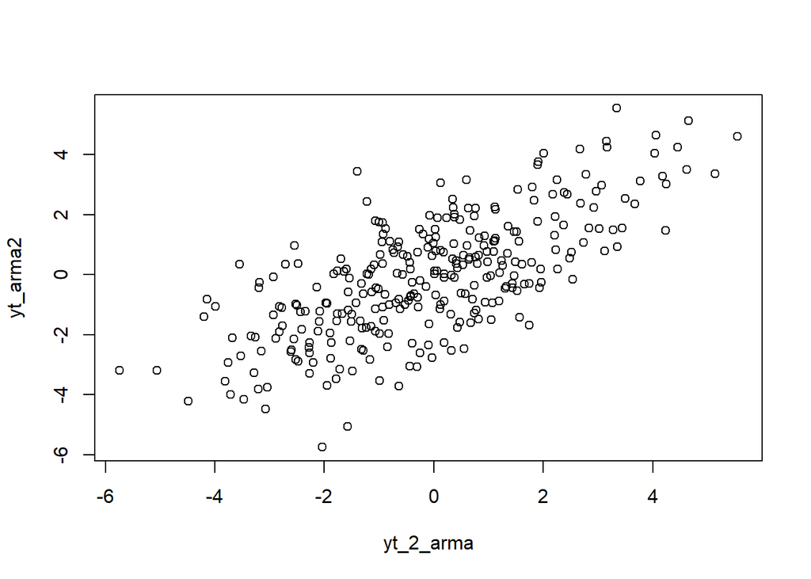

```r
plot(y=yt_arma2,x=yt_2_arma)
```

Berdasarkan scatterplot tersebut, terlihat bahwa terdapat hubungan positif yang kuat antara $Y_t$ dengan $Y_{t-2}$.

```r
cor(yt_arma2,yt_2_arma)
```

```
## [1] 0.7084118
```

#### Korelasi antara $Y_t$ dengan $Y_{t-3}$

```r
#Yt
yt_arma3 <- arma22[-c(1,2,3)]
yt_arma3
```

```
##   [1] -3.470309617 -5.743742885 -4.148828037 -3.197704093 -0.819903026
##   [6] -0.442936555 -0.991818873 -3.044946992 -1.952655019 -3.754687035
##  [11] -3.682777642 -2.935157123 -2.098113252 -1.342661101 -1.563450671
##  [16] -1.541070838 -1.184768165 -0.111171690  0.009019617  0.910953687
##  [21]  0.033670377  0.979040694 -0.676173060  0.429885345  0.052961722
##  [26]  0.227346739  0.122464039  1.893085892  0.814741139  1.783379173
##  [31]  0.655069770  0.407492244  0.577818915  0.474541251 -0.640300621
##  [36] -1.580089342 -3.709177662 -5.057905650 -3.989785494 -3.189374588
##  [41] -1.055154282 -0.252699925 -0.426853691 -0.200969163 -0.730243327
##  [46]  1.349120240  0.740460595  0.710657767 -0.360138723 -0.825017278
##  [51] -0.641727000 -1.970406921 -0.806799685 -0.938453620  1.121029890
##  [56]  1.743740251  1.207771243 -0.286853607  0.063882934 -1.072499571
##  [61]  1.895963744  1.799310032  3.667833266  2.922666990  2.366318270
##  [66]  2.233230272  1.655082316  0.821853045 -0.308906801 -1.485586663
##  [71] -3.070203997 -3.212259642 -4.482913418 -3.810224905 -4.203783992
```

[output cut: 45 more lines]

```r
#Yt-2
yt_3_arma <- arma22[-c(298,299,300)]
yt_3_arma
```

```
##   [1] -3.341346080 -1.780719192 -2.044055246 -3.470309617 -5.743742885
##   [6] -4.148828037 -3.197704093 -0.819903026 -0.442936555 -0.991818873
##  [11] -3.044946992 -1.952655019 -3.754687035 -3.682777642 -2.935157123
##  [16] -2.098113252 -1.342661101 -1.563450671 -1.541070838 -1.184768165
##  [21] -0.111171690  0.009019617  0.910953687  0.033670377  0.979040694
##  [26] -0.676173060  0.429885345  0.052961722  0.227346739  0.122464039
##  [31]  1.893085892  0.814741139  1.783379173  0.655069770  0.407492244
##  [36]  0.577818915  0.474541251 -0.640300621 -1.580089342 -3.709177662
##  [41] -5.057905650 -3.989785494 -3.189374588 -1.055154282 -0.252699925
##  [46] -0.426853691 -0.200969163 -0.730243327  1.349120240  0.740460595
##  [51]  0.710657767 -0.360138723 -0.825017278 -0.641727000 -1.970406921
##  [56] -0.806799685 -0.938453620  1.121029890  1.743740251  1.207771243
##  [61] -0.286853607  0.063882934 -1.072499571  1.895963744  1.799310032
##  [66]  3.667833266  2.922666990  2.366318270  2.233230272  1.655082316
##  [71]  0.821853045 -0.308906801 -1.485586663 -3.070203997 -3.212259642
```

[output cut: 45 more lines]

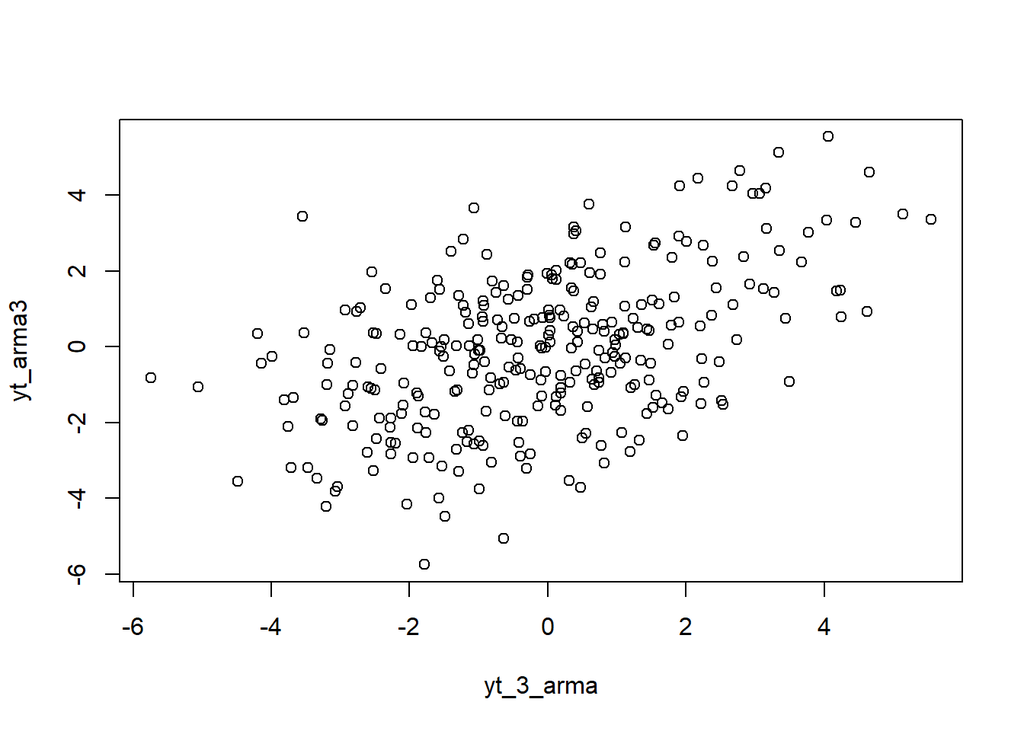

```r
plot(y=yt_arma3,x=yt_3_arma)
```

```r
cor(yt_arma3,yt_3_arma)
```

```
## [1] 0.4800942
```

#### Korelasi Secara Teoritis

```r
# Parameter
phi1 <- 0.5
phi2 <- 0.2
theta1 <- 0.4
theta2 <- 0.6
sigma2 <- 1   # bisa 1 karena rho tidak tergantung sigma2

# Banyak psi yang dihitung (M besar untuk aproksimasi)
M <- 200

# Hitung psi_j
psi <- numeric(M+1)
psi[1] <- 1            # psi_0 = 1  -> index 1 di R
if (M >= 1) psi[2] <- phi1 * psi[1] + theta1  # psi_1
if (M >= 2) psi[3] <- phi1 * psi[2] + phi2 * psi[1] + theta2  # psi_2
if (M >= 3) {
  for (k in 4:(M+1)) { # k di R index = j+1
    psi[k] <- phi1 * psi[k-1] + phi2 * psi[k-2]
  }
}

# Fungsi untuk gamma_k aproksimasi
gamma_k <- function(k, psi_vec) {
  # gamma_k = sum_{j=0..M-k} psi_j * psi_{j+k}
  # indeks R: psi[j+1] * psi[j+k+1]
  M <- length(psi_vec) - 1
  s <- 0
  for (j in 0:(M - k)) {
    s <- s + psi_vec[j+1] * psi_vec[j+k+1]
  }
  return(s * sigma2)
}

# Hitung gamma_0, gamma_1, gamma_2, gamma_3
gamma0 <- gamma_k(0, psi)
gamma1 <- gamma_k(1, psi)
gamma2 <- gamma_k(2, psi)
gamma3 <- gamma_k(3, psi)

# Autokorelasi
rho1 <- gamma1 / gamma0
rho2 <- gamma2 / gamma0
rho3 <- gamma3 / gamma0

# Tampilkan
rho1; rho2; rho3
```

```
## [1] 0.8591993
```

```
## [1] 0.7491908
```

```
## [1] 0.5464353
```

Korelasi antara $Y_t$ dengan $Y_{t-1}$, korelasi antara $Y_t$ dengan $Y_{t-2}$ dan korelasi $Y_t$ dengan $Y_{t-3}$ dari hasil simulasi mendekati perhitungan teoritis.